```python
from IPython.display import HTML

HTML('''<script>
code_show=true;
function code_toggle() {
 if (code_show){
 $('div.input').hide();
 } else {
 $('div.input').show();
 }
 code_show = !code_show
}
$( document ).ready(code_toggle);
</script>
<form action="javascript:code_toggle()"><input type="submit" value="Magic Button."></form>''')
```

```python
import plotly
from plotly.offline import init_notebook_mode, iplot
import plotly.graph_objs as go
init_notebook_mode()
```

# Probability

Probability is used to understand *uncertain*, or *random* situations. This means that we do not know what will happen.

Examples:

- Coin flip
- Card games
- Roulette
- Quantum Physics

# Definitions

- Experiment: a repeatable procedure with a set of possible results.
- Outcome: A possible result of an experiment.
- Sample Space: all the possible outcomes of an experiment.
- Sample Point: just one of the possible outcomes
- The probability $p$ of an *event* is between 0 and 1
- $P(A)$ is the probability that $A$ happens
- Impossible event : $p=0$
- Certain event : $p=1$

# Example

- Fair Coin Flip: P(heads) = 1/2
- Fair dice roll $P(1) = 1/6$, $P(2) = 1/6$

# How to Beat the Casino

## Warning: Do not do this!!!!!!!! It is very risky

# Roulette

- European roulette wheel: has 37 outcomes (0-36).
- 0 is green
- 18 spots are black
- 18 are red
- You can bet chips on red or black
- $P(red)=18/37 = 0.486$
- $P(black)=18/37 = 0.486$
- $P(green)=1/37 =0.027$

# Why the Casino likes Roulette

- The casino has a $\frac{19}{37}$ chance of winning a spin
- You have a $\frac{18}{37}$ chance of winning a spin
- This means that the casino has an 'edge' or advantage over you

# How to Beat the Casino

# Your Only Advantage

- You can decide when to stop playing. The casino has to let you keep playing

# Martingale Strategy

- Bet \$1
- If you lose the spin, double your bet and spin again
- If you win, stop playing
- You will always win \$1. But how???? Let's see!

```python
import pandas as pd
import numpy as np
n = 21
turn = pd.Series(np.arange(0,n,1), name = 'turn')
current_bet = 2**turn
df = pd.DataFrame({'current bet':current_bet},index=turn)
df['total loss'] = df['current bet'].expanding().sum()
df['payout if you win on this turn'] =  current_bet * 2
df['$ profit'] = np.ones(n)
p = 18/37
df['probability you will win before this turn'] = 1 - (1-p) ** turn
df.style
```

| turn | current bet | total loss | payout if you win on this turn | $ profit | probability you will win before this turn |
| --- | --- | --- | --- | --- | --- |
| 0 | 1 | 1 | 2 | 1 | 0 |
| 1 | 2 | 3 | 4 | 1 | 0.486486 |
| 2 | 4 | 7 | 8 | 1 | 0.736304 |
| 3 | 8 | 15 | 16 | 1 | 0.864588 |
| 4 | 16 | 31 | 32 | 1 | 0.930464 |
| 5 | 32 | 63 | 64 | 1 | 0.964293 |
| 6 | 64 | 127 | 128 | 1 | 0.981664 |
| 7 | 128 | 255 | 256 | 1 | 0.990584 |
| 8 | 256 | 511 | 512 | 1 | 0.995165 |
| 9 | 512 | 1023 | 1024 | 1 | 0.997517 |
| 10 | 1024 | 2047 | 2048 | 1 | 0.998725 |
| 11 | 2048 | 4095 | 4096 | 1 | 0.999345 |
| 12 | 4096 | 8191 | 8192 | 1 | 0.999664 |
| 13 | 8192 | 16383 | 16384 | 1 | 0.999827 |
| 14 | 16384 | 32767 | 32768 | 1 | 0.999911 |
| 15 | 32768 | 65535 | 65536 | 1 | 0.999954 |
| 16 | 65536 | 131071 | 131072 | 1 | 0.999977 |
| 17 | 131072 | 262143 | 262144 | 1 | 0.999988 |
| 18 | 262144 | 524287 | 524288 | 1 | 0.999994 |
| 19 | 524288 | 1.04858e+06 | 1048576 | 1 | 0.999997 |
| 20 | 1048576 | 2.09715e+06 | 2097152 | 1 | 0.999998 |

```python
df2 = df.copy()
df2 *= 5
df2['probability you will win before this turn'] = 1 - (1-p) ** turn
df2.style
```

| turn | current bet | total loss | payout if you win on this turn | $ profit | probability you will win before this turn |
| --- | --- | --- | --- | --- | --- |
| 0 | 5 | 5 | 10 | 5 | 0 |
| 1 | 10 | 15 | 20 | 5 | 0.486486 |
| 2 | 20 | 35 | 40 | 5 | 0.736304 |
| 3 | 40 | 75 | 80 | 5 | 0.864588 |
| 4 | 80 | 155 | 160 | 5 | 0.930464 |
| 5 | 160 | 315 | 320 | 5 | 0.964293 |
| 6 | 320 | 635 | 640 | 5 | 0.981664 |
| 7 | 640 | 1275 | 1280 | 5 | 0.990584 |
| 8 | 1280 | 2555 | 2560 | 5 | 0.995165 |
| 9 | 2560 | 5115 | 5120 | 5 | 0.997517 |
| 10 | 5120 | 10235 | 10240 | 5 | 0.998725 |
| 11 | 10240 | 20475 | 20480 | 5 | 0.999345 |
| 12 | 20480 | 40955 | 40960 | 5 | 0.999664 |
| 13 | 40960 | 81915 | 81920 | 5 | 0.999827 |
| 14 | 81920 | 163835 | 163840 | 5 | 0.999911 |
| 15 | 163840 | 327675 | 327680 | 5 | 0.999954 |
| 16 | 327680 | 655355 | 655360 | 5 | 0.999977 |
| 17 | 655360 | 1.31072e+06 | 1310720 | 5 | 0.999988 |
| 18 | 1310720 | 2.62144e+06 | 2621440 | 5 | 0.999994 |
| 19 | 2621440 | 5.24288e+06 | 5242880 | 5 | 0.999997 |
| 20 | 5242880 | 1.04858e+07 | 10485760 | 5 | 0.999998 |

# Formula

$$\sum _{k = 0} ^ {k=n-1} 2^k = 2^n - 1 $$

This formula is true as for any $n \geq 1$

# Not so Fast: Why this doesn't really work :(

Problem #1

This strategy could take a long time to finish, so you may owe a large amount of money before you win

Problem #2.

- Your *bankroll* is how much money you have to bet with. If you run out of money to bet with, you have to stop playing and will not make any money back.

Problem #3

- Real casinos have *betting limitations*. You can only make bets up to a certain size. For example, maybe you can only bet between \$1 and $\64. You cannot keep doubling

# Law of Large Numbers

# Monte Carlo

You can use *monte carlo experiments* to figure out a probability that you don't know exactly.

# Example:

I think that my coin is *unfair*. This means that the probability of heads is not the same as the probability of tails. I flip my coin $1.000$ times, and see $800$ heads and $200$ tails. I estimate that means that my coin actually has $.8$ probability of heads and $.2$ probability of tails.

# Calculating $\pi$

You may have seen $pi=3.14159....$

But how can you calculate it?

Draw a circle of radius $1$ inside a square with side length $2$.

# Probability

If I randomly and uniformally pick a point in the square, the probability that the point is in the circle is

$$p = \frac{\text{area of circle}}{\text{area of entire square}}$$

- The area of the circle is $\pi r^2 = \pi 1^2 = \pi$
- The area of the square is $s^2 = 2^2 = 4$

$$ p = \frac{\pi}{4}$$

# Law of Large Numbers

# Circle Equation

- The formula for a circle is $$r^2 = x^2 + y^2$$
- Here, $r=1\implies 1 = x^2 + y^2$
- Any point inside the circle will have $x^2 + y^2 \leq 1$
- Any point outside the circle will have $x^2 + y^2 > 1$

```python
import numpy as np
import matplotlib.pyplot as plt

def graph(N):

    X = np.random.uniform(-1,1,N)

    Y = np.random.uniform(-1,1,N)

    inside = (X**2 + Y**2) < 1

    s=10

    pi = 4 * inside.sum() / N
    print(pi)
    plt.figure(figsize=[5,5])
    plt.axis(xmin=-1,ymin=-1,xmax=1,ymax=1)
    plt.scatter(X[~ inside],Y[~ inside],s=s)
    plt.scatter(X[inside], Y[inside], color = 'r',s=s)
    print("N=",N)
    print("pi=" + str(pi))
    plt.show()
```

```
0.0
N= 1
pi=0.0
```

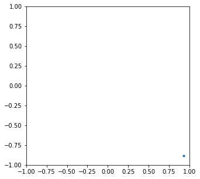

```
2.8
N= 10
pi=2.8
```

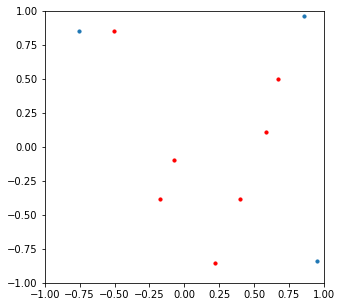

```
3.08
N= 100
pi=3.08
```

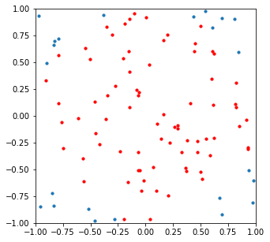

```
3.104
N= 1000
pi=3.104
```

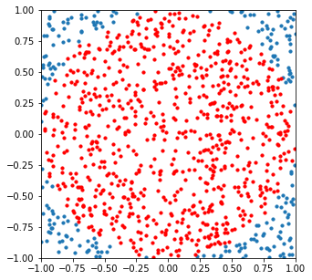

```
3.1124
N= 10000
pi=3.1124
```

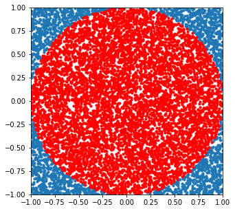

```
3.13252
N= 100000
pi=3.13252
```

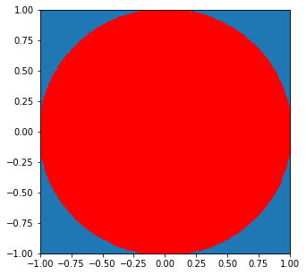

```
3.1417
N= 1000000
pi=3.1417
```

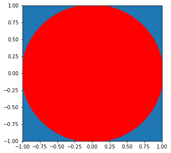

```
3.1415636
N= 10000000
pi=3.1415636
```

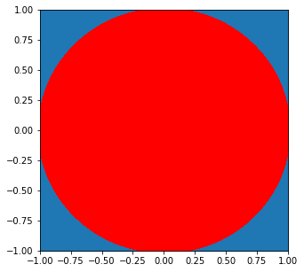

```python
for n in range(8):
    graph(10**n)
```